# What Defines a Successful Kickstart? Can You Predict a Failure?

Analyzing Kickstarter data to visualize and predict the success or failure of a campaign.

Author: Lucas Ference

## Introduction:

Recently, crowdfunding has taken off. This is evident with the massive success of a website called Kickstarter. Anyone that has an idea for a company or product can start a campaign on Kickstarter, where the public can help fund their project. Ultimately, the campaign can fail or succeed, depending on if the goal was reached or not. Supporters (also called backers) can "pledge" a predefined amount of money, which is decided by the campaign creator. For example, a project may have three payment "packages". Below is a picture of some of the packages for a project called LUNEdot Candle.

[figure not shown]

By pledging to either of these packages, the backer should expect to receive what is described in the package if the project ends up being successful.

## Getting Started

### Required Libraries

```python
import pandas as pd
import matplotlib.pyplot as plt
import seaborn as sns
import numpy as np
from sklearn import linear_model
from statsmodels import api as sm
```

### Dataset Source

The dataset used includes information regarding over 300,000 kickstarter campaigns. It includes the category, the deadline and time launched, its current state (failed, canceled, success, live, or suspended), how many backers it had/has (amount of people donating to the campaign), and the total amount pledged.

This dataset was found on Kaggle. The curator of the dataset also converted all amounts spent into USD, which makes our lives a little easier since we will not have to convert any of the data.

Kaggle dataset: https://www.kaggle.com/kemical/kickstarter-projects#ks-projects-201801.csv

### Load/View Data

The data is read directly from a CSV, and the first five rows are displayed below.

```python
kickstarts = pd.read_csv('kickstarts.csv')
kickstarts.head()
```

|  | ID | name | category | main_category | currency | deadline | goal | launched | pledged | state | backers | country | usd pledged | usd_pledged_real | usd_goal_real |
| --- | --- | --- | --- | --- | --- | --- | --- | --- | --- | --- | --- | --- | --- | --- | --- |
| 0 | 1000002330 | The Songs of Adelaide & Abullah | Poetry | Publishing | GBP | 2015-10-09 | 1000.0 | 2015-08-11 12:12:28 | 0.0 | failed | 0 | GB | 0.0 | 0.0 | 1533.95 |
| 1 | 1000003930 | Greeting From Earth: ZGAC Arts Capsule For ET | Narrative Film | Film & Video | USD | 2017-11-01 | 30000.0 | 2017-09-02 04:43:57 | 2421.0 | failed | 15 | US | 100.0 | 2421.0 | 30000.00 |
| 2 | 1000004038 | Where is Hank? | Narrative Film | Film & Video | USD | 2013-02-26 | 45000.0 | 2013-01-12 00:20:50 | 220.0 | failed | 3 | US | 220.0 | 220.0 | 45000.00 |
| 3 | 1000007540 | ToshiCapital Rekordz Needs Help to Complete Album | Music | Music | USD | 2012-04-16 | 5000.0 | 2012-03-17 03:24:11 | 1.0 | failed | 1 | US | 1.0 | 1.0 | 5000.00 |
| 4 | 1000011046 | Community Film Project: The Art of Neighborhoo... | Film & Video | Film & Video | USD | 2015-08-29 | 19500.0 | 2015-07-04 08:35:03 | 1283.0 | canceled | 14 | US | 1283.0 | 1283.0 | 19500.00 |

Below is some interesting information regarding the above data. We are going to be using 'usd_pledged_real' and 'usd_goal_real' to define the amount pledged and the the goal of the project. These values have already been converted for us, and 'usd pledged' is a conversion done by Kickstarter, which is actually incorrect. I find it interesting that the mean USD pledged (usd_pledged_real) is ~9000 dollars, while the mean USD goals (usd_goal_real) is ~45,000 dollars. I expected the USD pledged to be lower, but not by this much. This probably indicates a large amount of projects with high goals that have failed very quickly without recieving much support. We will be sure to explore this further later on.

```python
kickstarts.describe()
```

|  | ID | goal | pledged | backers | usd pledged | usd_pledged_real | usd_goal_real |
| --- | --- | --- | --- | --- | --- | --- | --- |
| count | 3.786610e+05 | 3.786610e+05 | 3.786610e+05 | 378661.000000 | 3.748640e+05 | 3.786610e+05 | 3.786610e+05 |
| mean | 1.074731e+09 | 4.908079e+04 | 9.682979e+03 | 105.617476 | 7.036729e+03 | 9.058924e+03 | 4.545440e+04 |
| std | 6.190862e+08 | 1.183391e+06 | 9.563601e+04 | 907.185035 | 7.863975e+04 | 9.097334e+04 | 1.152950e+06 |
| min | 5.971000e+03 | 1.000000e-02 | 0.000000e+00 | 0.000000 | 0.000000e+00 | 0.000000e+00 | 1.000000e-02 |
| 25% | 5.382635e+08 | 2.000000e+03 | 3.000000e+01 | 2.000000 | 1.698000e+01 | 3.100000e+01 | 2.000000e+03 |
| 50% | 1.075276e+09 | 5.200000e+03 | 6.200000e+02 | 12.000000 | 3.947200e+02 | 6.243300e+02 | 5.500000e+03 |
| 75% | 1.610149e+09 | 1.600000e+04 | 4.076000e+03 | 56.000000 | 3.034090e+03 | 4.050000e+03 | 1.550000e+04 |
| max | 2.147476e+09 | 1.000000e+08 | 2.033899e+07 | 219382.000000 | 2.033899e+07 | 2.033899e+07 | 1.663614e+08 |

### Cleaning the Data

The first thing we need to do is decide which columns we want to analyze. We are going to drop columns which do not help us in our exploration/analysis, making the table easier to examine since it won't be cluttered with unneccesary data.

The only columns we want to analyze will be the main category, its current state (success, failure, etc.), the amount of backers this project had/has, the country of origin, the amount pledged in USD, and the project's goal in USD.

```python
# Drop the unneccesary columns.
kickstarts = kickstarts.drop(['category', 'currency', 'deadline', 'launched',
                              'name', 'usd pledged', 'goal', 'pledged'], axis=1)

# Rename the columns so they are easier to work with.
kickstarts.columns = ['id', 'category', 'state', 'backers', 'country', 'pledged', 'goal']
kickstarts.head()
```

|  | id | category | state | backers | country | pledged | goal |
| --- | --- | --- | --- | --- | --- | --- | --- |
| 0 | 1000002330 | Publishing | failed | 0 | GB | 0.0 | 1533.95 |
| 1 | 1000003930 | Film & Video | failed | 15 | US | 2421.0 | 30000.00 |
| 2 | 1000004038 | Film & Video | failed | 3 | US | 220.0 | 45000.00 |
| 3 | 1000007540 | Music | failed | 1 | US | 1.0 | 5000.00 |
| 4 | 1000011046 | Film & Video | canceled | 14 | US | 1283.0 | 19500.00 |

Now we will want to drop all the rows with any null values. We do this since a row with a null value is not of any use to us, and can affect our data negatively. For example, if a column had a null value in the amount pledged, it could misrepresent the data since that value will not be known.

```python
kickstarts = kickstarts[pd.notnull(kickstarts['category'])]
kickstarts = kickstarts[pd.notnull(kickstarts['state'])]
kickstarts = kickstarts[pd.notnull(kickstarts['backers'])]
kickstarts = kickstarts[pd.notnull(kickstarts['country'])]
kickstarts = kickstarts[pd.notnull(kickstarts['pledged'])]
kickstarts = kickstarts[pd.notnull(kickstarts['goal'])]

kickstarts.describe()
```

|  | id | backers | pledged | goal |
| --- | --- | --- | --- | --- |
| count | 3.786610e+05 | 378661.000000 | 3.786610e+05 | 3.786610e+05 |
| mean | 1.074731e+09 | 105.617476 | 9.058924e+03 | 4.545440e+04 |
| std | 6.190862e+08 | 907.185035 | 9.097334e+04 | 1.152950e+06 |
| min | 5.971000e+03 | 0.000000 | 0.000000e+00 | 1.000000e-02 |
| 25% | 5.382635e+08 | 2.000000 | 3.100000e+01 | 2.000000e+03 |
| 50% | 1.075276e+09 | 12.000000 | 6.243300e+02 | 5.500000e+03 |
| 75% | 1.610149e+09 | 56.000000 | 4.050000e+03 | 1.550000e+04 |
| max | 2.147476e+09 | 219382.000000 | 2.033899e+07 | 1.663614e+08 |

It seems that all the values stayed virtually the same, meaning the dataset was complete. This if very good for our upcoming analysis since we do not have worry about missing data (i.e. missing at random, etc.).

While this dataset is very clean and well put together, I noticed a few anomalies that should be removed from our dataset.

- Some projects are marked successful but have 0 backers.
- Projects are marked successful even if the goal was not reached.
- Projects marked as failed even though the goal was reached.

There are not a significant amount of rows that meet these conditions, but they should be removed regardless.

```python
for i, row in kickstarts.iterrows():
    if (row.state == 'successful' and row.backers == 0):
        kickstarts.drop(i, inplace=True)
    if (row.goal > row.pledged and row.state == 'successful'):
        kickstarts.drop(i, inplace=True)
    if (row.goal < row.pledged and row.state == 'failed'):
        kickstarts.drop(i, inplace=True)

kickstarts.describe()
```

|  | id | backers | pledged | goal |
| --- | --- | --- | --- | --- |
| count | 3.785470e+05 | 378547.000000 | 3.785470e+05 | 3.785470e+05 |
| mean | 1.074747e+09 | 105.646728 | 9.052829e+03 | 4.546614e+04 |
| std | 6.190963e+08 | 907.319835 | 9.087685e+04 | 1.153123e+06 |
| min | 5.971000e+03 | 0.000000 | 0.000000e+00 | 1.000000e-02 |
| 25% | 5.382378e+08 | 2.000000 | 3.100000e+01 | 2.000000e+03 |
| 50% | 1.075338e+09 | 12.000000 | 6.230000e+02 | 5.500000e+03 |
| 75% | 1.610163e+09 | 56.000000 | 4.047410e+03 | 1.550000e+04 |
| max | 2.147476e+09 | 219382.000000 | 2.033899e+07 | 1.663614e+08 |

As you can see from above, the change in data after cleaning it was extremely minor, but still worthwhile to do.

While examining the data, I noticed something interesting. The state of the project has 6 total values. It could either be successful, failed, canceled, live, suspended, or undefined. For this experiment, we are only examining past projects and their results. We will want to remove all projects that are currently in progress, or were canceled/suspended. I want to remove canceled/suspended projects since it is unclear what they mean. Maybe they were going to be extremely successful, but were canceled/suspended due to unforseen circumstances involving their family, job, etc. They also could have also been failing so miserably that the projects were deleted out of shame. Because of these unforseen circumstances that we will never know, we will remove these rows.

```python
kickstarts = kickstarts[kickstarts.state != 'live']
kickstarts = kickstarts[kickstarts.state != 'suspended']
kickstarts = kickstarts[kickstarts.state != 'undefined']
kickstarts = kickstarts[kickstarts.state != 'canceled']

print(kickstarts.state.unique())
```

```
['failed' 'successful']
```

Just to ensure there was nothing else we missed, we printed out the unique values above.

### Numerically Identifying the Data

When performing data analysis it can be very useful to give non-numerical data a numerical counterpart. In our analysis we will need to associate a number with multiple different columns.

We will need to associate a number with the state. Associating a failure with 0 and a success with 1 should do just fine. This is very useful in calculating the percentage of success easily and for performing some machine learning later on.

```python
kickstarts['success'] = 0
kickstarts.loc[kickstarts['state'] == 'successful', 'success'] = 1
kickstarts.head()
```

|  | id | category | state | backers | country | pledged | goal | success |
| --- | --- | --- | --- | --- | --- | --- | --- | --- |
| 0 | 1000002330 | Publishing | failed | 0 | GB | 0.0 | 1533.95 | 0 |
| 1 | 1000003930 | Film & Video | failed | 15 | US | 2421.0 | 30000.00 | 0 |
| 2 | 1000004038 | Film & Video | failed | 3 | US | 220.0 | 45000.00 | 0 |
| 3 | 1000007540 | Music | failed | 1 | US | 1.0 | 5000.00 | 0 |
| 5 | 1000014025 | Food | successful | 224 | US | 52375.0 | 50000.00 | 1 |

## Exploring State Data

The first thing I would like to do is examine general traits about successful and failed projects. Starting with general data about the two obvserved states can help set the stage for further evaluation later on.

Below I have plotted the percentage of projects that fail compared to the amount of projects that succeed.

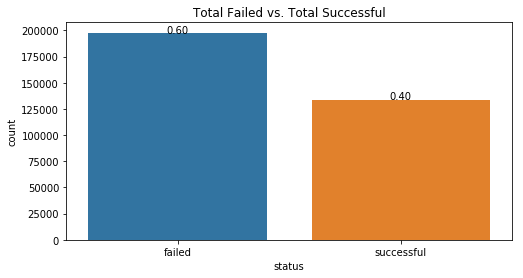

```python
# Group by the state and calculate the total amount that fail and the total amount successful.
counts = kickstarts.groupby('state').count().reset_index()[['state', 'id']]
counts.columns = ['status', 'count']

total = float(len(kickstarts))

plt.figure(figsize=(8,4))
plt.title('Total Failed vs. Total Successful')
ax = sns.barplot(x='status', y='count', data=counts)
for p in ax.patches:
    height = p.get_height()
    ax.text(p.get_x() + p.get_width()/2.,
           height+5,
           '{:1.2f}'.format(height/total),
           ha='center')

plt.show()
```

Anyway, let's analyze some of the data associated with successful campaigns and failed campaigns.

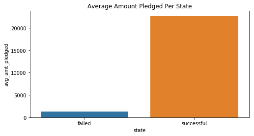

```python
ttl_pledged = kickstarts.groupby('state').mean().reset_index()[['state', 'pledged']]
ttl_pledged.columns = ['state', 'avg_amt_pledged']

plt.figure(figsize=(8,4))
plt.title('Average Amount Pledged Per State')
sns.barplot(x='state', y='avg_amt_pledged', data=ttl_pledged)
plt.show()
```

Not surprisingly, the average amount pledged towards successful projects is significantly more (that is what makes them successful). I just think it is interesting to quickly view the massive difference in these values before we proceed.

Next, let's analyze the median goals for successful and failed projects. The reason I choose median is because average could be heavily affected by outliers (some projects could make their goals over one billion dollars, but that is obviously not representative of the entire dataset).

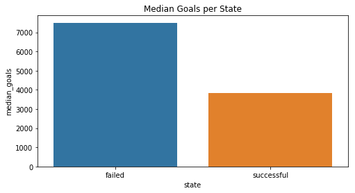

```python
# Median goals
med_goals = kickstarts.groupby('state').median().reset_index()[['state', 'goal']]
med_goals.columns = ['state', 'median_goals']

plt.figure(figsize=(8,4))
plt.title('Median Goals per State')
sns.barplot(x='state', y='median_goals', data=med_goals)
plt.show()
```

It seems that the median of failed projects is significantly more than successful projects. It is likely that the higher goals are harder to reach, leading to more failed projects. It could also be possible that backers are less likely to pledge to a project with a higher goal for various reasons. This can not be inferred from the dataset however, so we will not consider this going forward.

Now that we have looked at general data about the project's state, we will proceed to analyze the categories and data associated with them. This will likely be more interesting and further strengthen our predictions or analysis later on.

## Analyzing Category Data

To start our category analysis, we should look at the total amount of projects within each category. Some categories will surely be more popular than others, which could be associated with their success percentages (maybe more popular categories have lower success percentages due to the fact that they are "watered down" and many projects go unnoticed).

We will also include the categories success percentage to set the stage for our analysis.

```python
category = kickstarts.groupby('category').count().reset_index()[['category', 'id']]
category.columns = ['category', 'count']
category = category.sort_values('count', ascending=False)

win_pct = kickstarts.groupby('category').mean().reset_index()[['category', 'success']]
category = pd.merge(category, win_pct, on='category', how='inner')
category
```

|  | category | count | success |
| --- | --- | --- | --- |
| 0 | Film & Video | 56514 | 0.417773 |
| 1 | Music | 45855 | 0.525679 |
| 2 | Publishing | 35444 | 0.347026 |
| 3 | Games | 28521 | 0.438905 |
| 4 | Technology | 27049 | 0.237828 |
| 5 | Art | 25639 | 0.448847 |
| 6 | Design | 25361 | 0.415914 |
| 7 | Food | 22054 | 0.275914 |
| 8 | Fashion | 19775 | 0.282832 |
| 9 | Theater | 10242 | 0.637961 |
| 10 | Comics | 9878 | 0.591415 |
| 11 | Photography | 9689 | 0.341108 |
| 12 | Crafts | 7818 | 0.270530 |
| 13 | Journalism | 4149 | 0.243914 |
| 14 | Dance | 3573 | 0.654352 |

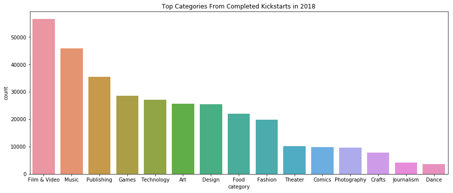

```python
plt.figure(figsize=(15,6))
plt.title("Top Categories From Completed Kickstarts in 2018")
sns.barplot(x='category', y='count', data=category)
plt.show()
```

### Pledged To Goal Ratio

First, I would like to find the percent of the goal reached for each project. We will do this by dividing the amount pledged by the goal and multiplying by 100.

```python
# First find the difference percentage for each project.

difference = kickstarts.copy()
difference['diff_pct'] = 0.0

difference['diff_pct'] = 100 * (difference['pledged'] / difference['goal'])

difference.head()
```

|  | id | category | state | backers | country | pledged | goal | success | diff_pct |
| --- | --- | --- | --- | --- | --- | --- | --- | --- | --- |
| 0 | 1000002330 | Publishing | failed | 0 | GB | 0.0 | 1533.95 | 0 | 0.000000 |
| 1 | 1000003930 | Film & Video | failed | 15 | US | 2421.0 | 30000.00 | 0 | 8.070000 |
| 2 | 1000004038 | Film & Video | failed | 3 | US | 220.0 | 45000.00 | 0 | 0.488889 |
| 3 | 1000007540 | Music | failed | 1 | US | 1.0 | 5000.00 | 0 | 0.020000 |
| 5 | 1000014025 | Food | successful | 224 | US | 52375.0 | 50000.00 | 1 | 104.750000 |

We have now calculated the difference percentage for each project. We can now group by each category so we can compare these percentages across categories. There is one problem however, comparing across the categories directly could give innacurate results. There is a wide range in the total projects for each category, as well as a wide range in goals.

Because of this, we will standardize the percentage by calculating the Z score for each row by first getting the average percentage and standard deviation. After calculating the Z score for every row we will average the Z scores for each category. For more information regarding Z scores and standardization, go [here](https://statistics.laerd.com/statistical-guides/standard-score.php)

```python
# Create a table for calculating the Z scores.
calc = difference.copy()

# Calculate the average percentage.
avg_diff = calc['diff_pct'].mean()

# Calculate the standard deviation of diff_pct.
std_dev = calc['diff_pct'].std()

calc['z_score'] = 0

# Calculate the Z score for each project.
calc['z_score'] = (calc['diff_pct'] - avg_diff) / std_dev

# Get the average Z score for each category.
z_scores = calc.groupby('category').mean().reset_index()[['category', 'z_score']]
z_scores.columns = ['category', 'avg_z_score']
z_scores = z_scores.sort_values('avg_z_score', ascending=False)

z_scores
```

|  | category | avg_z_score |
| --- | --- | --- |
| 10 | Music | 0.018805 |
| 8 | Games | 0.016955 |
| 1 | Comics | 0.012158 |
| 13 | Technology | -0.001631 |
| 2 | Crafts | -0.002808 |
| 0 | Art | -0.002833 |
| 4 | Design | -0.004339 |
| 12 | Publishing | -0.005643 |
| 6 | Film & Video | -0.006687 |
| 14 | Theater | -0.008677 |
| 5 | Fashion | -0.008722 |
| 7 | Food | -0.009182 |
| 3 | Dance | -0.009432 |
| 11 | Photography | -0.010168 |
| 9 | Journalism | -0.010425 |

Now that we have the average Z score for each category, we should graph it to visualize the differences among categories.

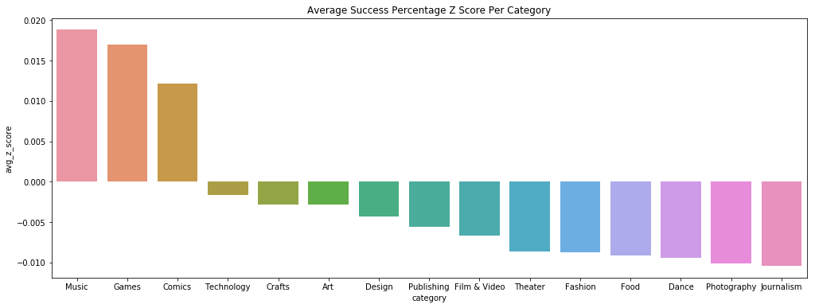

```python
plt.figure(figsize=(17,6))
plt.title("Average Success Percentage Z Score Per Category")
sns.barplot(x='category', y='avg_z_score', data=z_scores)
plt.show()
```

The average Z scores in this case represent the standardized success percentage for each category. In this case, the higher the Z score the better, since it is directly related to the difference percentage for a project in a certain category.

Because a category's Z score could have multiple implications, we should attempt to apply it and find any correlation between the Z score and success. Would a higher Z score indicate a higher percent?

Let's create a table with three attributes: category, average Z score, and success percentage.

```python
avg_success = category[['category', 'success']].copy()

avg_success['success'] = avg_success['success'] * 100

combined = pd.merge(z_scores, avg_success, on='category', how='inner')
combined.columns = ['category', 'avg_z_score', 'success_pct']
combined.head()
```

|  | category | avg_z_score | success_pct |
| --- | --- | --- | --- |
| 0 | Music | 0.018805 | 52.567877 |
| 1 | Games | 0.016955 | 43.890467 |
| 2 | Comics | 0.012158 | 59.141527 |
| 3 | Technology | -0.001631 | 23.782765 |
| 4 | Crafts | -0.002808 | 27.052955 |

Now that we have related the category to the Z score and the success percentage, we should graph this and see if there is a correlation. If we define the X-axis as the average Z score and the Y-axis as the success percentage, we should hopefully find some correlation.

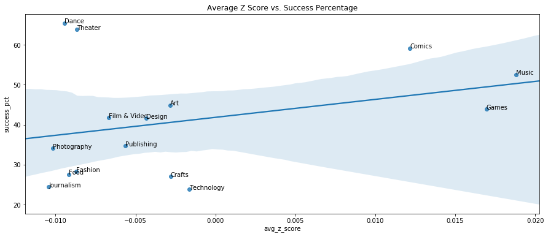

```python
plt.figure(figsize=(15,6))
plt.title('Average Z Score vs. Success Percentage')
sns.regplot(x='avg_z_score', y='success_pct', data=combined)

def label_point(x, y, val, ax):
    a = pd.concat({'x': x, 'y': y, 'val': val}, axis=1)
    for i, point in a.iterrows():
        ax.text(point['x'], point['y'], str(point['val']))

label_point(combined.avg_z_score, combined.success_pct, combined.category, plt.gca())
```

### Average Spent Per Backer

Every project has a certain amount of backers, which contribute fully to the goal. If certain categories draw more passion from the crowd that it attracts, it may be able to get a larger amount of money per backer. Do these categories exist? If they do exist, do they have a higher percentage of success? Let's find out...

First, we need to find the average amount each backer pledges for each row.

```python
avg_per_backer = kickstarts.copy()
avg_per_backer['avg_per_backer'] = 0.0

# Replace infinite or nan with 0 (amount of backers was 0).
avg_per_backer['avg_per_backer'] = (avg_per_backer['pledged'] / avg_per_backer['backers']) \
                                                            .replace(np.inf, 0).replace(np.nan, 0)

avg_per_backer.head()
```

|  | id | category | state | backers | country | pledged | goal | success | avg_per_backer |
| --- | --- | --- | --- | --- | --- | --- | --- | --- | --- |
| 0 | 1000002330 | Publishing | failed | 0 | GB | 0.0 | 1533.95 | 0 | 0.000000 |
| 1 | 1000003930 | Film & Video | failed | 15 | US | 2421.0 | 30000.00 | 0 | 161.400000 |
| 2 | 1000004038 | Film & Video | failed | 3 | US | 220.0 | 45000.00 | 0 | 73.333333 |
| 3 | 1000007540 | Music | failed | 1 | US | 1.0 | 5000.00 | 0 | 1.000000 |
| 5 | 1000014025 | Food | successful | 224 | US | 52375.0 | 50000.00 | 1 | 233.816964 |

Now we want to add up the total averages, but that leaves us with a similar problem as earlier. Some of the categories are going to have siginificantly higher values, since they vary widely in sizes. To overcome this, we are going to want to standardize the totals for each category.

```python
calc = avg_per_backer.copy()

avg = calc['avg_per_backer'].mean()

std_dev = calc['avg_per_backer'].std()

calc['z_scores'] = 0.0

# Calculate the Z score for each project.
calc['z_score'] = (calc['avg_per_backer'] - avg) / std_dev

# Get the average Z score for each category.
z_scores = calc.groupby('category').mean().reset_index()[['category', 'z_score']]
z_scores.columns = ['category', 'avg_z_score']
z_scores = z_scores.sort_values('avg_z_score', ascending=False)

z_scores
```

|  | category | avg_z_score |
| --- | --- | --- |
| 13 | Technology | 0.229298 |
| 4 | Design | 0.206592 |
| 6 | Film & Video | 0.094895 |
| 3 | Dance | 0.047048 |
| 14 | Theater | 0.040529 |
| 7 | Food | -0.012869 |
| 5 | Fashion | -0.016089 |
| 10 | Music | -0.050274 |
| 0 | Art | -0.072838 |
| 11 | Photography | -0.084197 |
| 8 | Games | -0.111051 |
| 12 | Publishing | -0.123876 |
| 1 | Comics | -0.183337 |
| 9 | Journalism | -0.198557 |
| 2 | Crafts | -0.205228 |

Now we plot on a histogram to visualize the average Z scores we just computed.

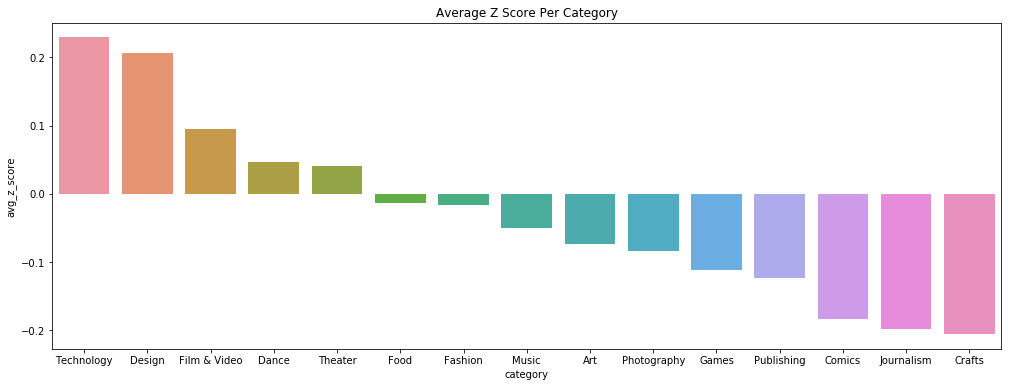

```python
plt.figure(figsize=(17,6))
plt.title("Average Z Score Per Category")
sns.barplot(x='category', y='avg_z_score', data=z_scores)
plt.show()
```

I think something interesting about data above is that it can be interpreted as the amount of passion driven by certain categories. What I mean by this is that a higher average per backer could mean that some people spend a significant amount more, which may be driven by their passion for the product. This is not super relevant to our exploration, but I thought it would be an interesting sidenote.

## Pledge Data vs. Success

Logically it makes sense that the more pledges a project has, the more likely that project is to succeed. I would like to confirm this belief by analyzing the success percentage vs. the average amount pledged. Instead of focusing on the categories and how they may differ, I will be focusing on "buckets" of data in the table, and how that "bucket" is correlated to success.

Below I have listed the steps I will be taking to perform this.

1) Order the kickstarts by average pledge amount per backer.  
2) Put every ~one thousand rows into a "bucket" and calculate the win percentage of that bucket.  
3) For every ~one thousand sum the total pledge amound and divide by the total number of backers to get the average pledge amount for the bucket.  
4) Plot that vs. the success percentage to find a relation.

Step 1: order the kickstart data

```python
ordered = kickstarts.copy()[['success', 'backers', 'pledged', 'goal']]
# Calculate average per backer.
ordered['avg_per_backer'] = (ordered['pledged'] / ordered['backers']).replace(np.inf, 0).replace(np.nan, 0)
# Sort values based on the average pledged per backer.
ordered = ordered.sort_values('avg_per_backer')
```

Step 2: Bucket every one thousand wins and calculate win percentage.

We will also be doing step 3 in this (to consolidate into one for loop).

Step 3: Get average donation amount per bucket.

```python
# Break the table into 300 different sections.
binned = np.array_split(ordered, 300)
cut = pd.DataFrame(columns=['success_pct', 'bucket_avg'])

# For each section, calculate the success percentage and add to ordered table.
for df in binned:
    pct = 100 * df['success'].mean()
    pledged = df['pledged'].sum()
    backers = df['backers'].sum()
    avg = 0.0
    if backers != 0:
        avg =  pledged / backers
    cut = cut.append({'success_pct': pct, 'bucket_avg': avg}, ignore_index=True)
```

Step 4: Plot the graph and let's observe the results!

Note: There was one outlier very far to the right side (a bucket average of around x = ~1215, y = ~42) that I removed to visualize the data better.

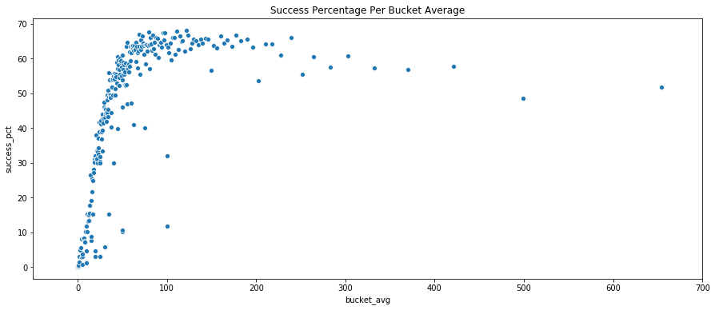

```python
plt.figure(figsize=(15,6))
# Hide the far right value.
plt.xlim(-50,700)
plt.title('Success Percentage Per Bucket Average')
sns.scatterplot(x='bucket_avg', y='success_pct', data=cut)
plt.show()
```

Wow! There are a few cool bits of information we can derive from this graph.

For the most part, it is as expected. As the bucket average spent per backer increases, so does the success percentage. From this you can infer that as each backer starts to pledge more, the chance of it being successful increases. It also increases at a rate similar to a logarithmic function (The effects of pledging become less as you pledge more).

What is also very peculiar is that the success percentage actually starts to decrease after a ~200 bucket average! It is not a dramatic decrease, but it is something to notice. Could it be that higher goals are associated with higher average spent per backer? We will repeat the same process as above, but sorted by goal rather than amount per backer.

```python
ordered = kickstarts.copy()[['success', 'backers', 'pledged', 'goal']]
# Sort values based on the goal.
ordered = ordered.sort_values('goal')

# Break the table into 300 different sections.
binned = np.array_split(ordered, 300)
cut = pd.DataFrame(columns=['success_pct', 'bucket_avg'])

# For each section, calculate the success percentage and add to ordered table.
for df in binned:
    pct = 100 * df['success'].mean()
    avg = df['goal'].mean()

    cut = cut.append({'success_pct': pct, 'bucket_avg': avg}, ignore_index=True)
```

Note: Some outliers on the right were cut off from the graph since they were not representative of the overall data

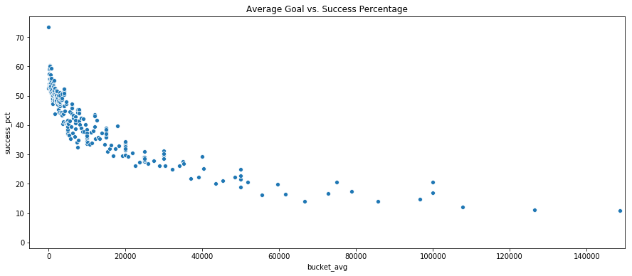

```python
plt.figure(figsize=(15,6))
# Hide the far right value.
plt.xlim(-5000,150000)

plt.title('Average Goal vs. Success Percentage')
sns.scatterplot(x='bucket_avg', y='success_pct', data=cut)
plt.show()
```

So another very interesting graph! The amount of clustering in the top left is very interesting. The graph follows a downward trend, which is somewhat expected from our previous data.

Interestingly enough, it seems to follow an opposite relation as the previous graph. It almost represents a reverse logarithmic function.

Since it seems that goal is definitely a factor in predicting success rate, we will continue to analyze it as we progress.

### Some Correlation?

Now that we analyzed the average amount per backer and goals' effects on success rate, I want to back it up a little bit and take a look at the correlation between attributes in our original Kickstarter table.

```python
selected = kickstarts.copy()
selected = selected[['success', 'goal', 'pledged', 'backers']]
selected.corr()
```

|  | success | goal | pledged | backers |
| --- | --- | --- | --- | --- |
| success | 1.000000 | -0.023729 | 0.108374 | 0.125868 |
| goal | -0.023729 | 1.000000 | 0.006349 | 0.005207 |
| pledged | 0.108374 | 0.006349 | 1.000000 | 0.753222 |
| backers | 0.125868 | 0.005207 | 0.753222 | 1.000000 |

It seems that goal has a negative correaltion with success! That makes me very curious as to how goal can be used as a predictor. We know that difference categories have different success percentages, but how significant is the goal set? We will explore this further by doing a little bit of logistic regression!

## Making Predictions With Machine Learning

Before we commence on our machine learning endeavor, it is smart to first prepare our data.

Earlier, we converted our project state to a 0 or 1, depending on if it failed or was successful. We are now going to do that again, but for our categories. Converting the category to a numerical value will give us the ability to use the category in various machine learning techniques.

```python
kickstarts['category'] = kickstarts['category'].astype('category')
kickstarts['category_code'] = kickstarts['category'].cat.codes

kickstarts.head()
```

|  | id | category | state | backers | country | pledged | goal | success | category_code |
| --- | --- | --- | --- | --- | --- | --- | --- | --- | --- |
| 0 | 1000002330 | Publishing | failed | 0 | GB | 0.0 | 1533.95 | 0 | 12 |
| 1 | 1000003930 | Film & Video | failed | 15 | US | 2421.0 | 30000.00 | 0 | 6 |
| 2 | 1000004038 | Film & Video | failed | 3 | US | 220.0 | 45000.00 | 0 | 6 |
| 3 | 1000007540 | Music | failed | 1 | US | 1.0 | 5000.00 | 0 | 10 |
| 5 | 1000014025 | Food | successful | 224 | US | 52375.0 | 50000.00 | 1 | 7 |

Since a couple of these columns are extremely definitive of a successful project, we are going to drop them. What I mean is that if we were to include the amount pledged and the goal in our regression model, we would obviously always be able to predict which ones were successful and which ones weren't. Due to this, we are going to remove certain attributes and create a new table to make it more clear what we are measuring.

```python
selected = kickstarts.copy()[['state', 'category', 'country', 'goal', 'success', 'category_code']]
selected.head()
```

|  | state | category | country | goal | success | category_code |
| --- | --- | --- | --- | --- | --- | --- |
| 0 | failed | Publishing | GB | 1533.95 | 0 | 12 |
| 1 | failed | Film & Video | US | 30000.00 | 0 | 6 |
| 2 | failed | Film & Video | US | 45000.00 | 0 | 6 |
| 3 | failed | Music | US | 5000.00 | 0 | 10 |
| 5 | successful | Food | US | 50000.00 | 1 | 7 |

### Null Hypothesis

Before we start, we should define our null hypothesis.

**None of the attributes attributes in our selected table have any effect on the final state of the project.**

Because we are attempting to predict a 0 or a 1 (success or failure), it would be best to use logistic regression. Logistic regression can be used to predict dependent binary variables. To read up further on this type of regression, click [here](https://machinelearningmastery.com/logistic-regression-for-machine-learning/).

```python
# Ignore warnings because of issues with Logit
import warnings
warnings.filterwarnings("ignore")

features = kickstarts[['goal', 'category_code']]
target = selected[['success']]
X = features
y = target['success']


clf = linear_model.LogisticRegression()

clf.fit(X, y)

score = clf.score(X, y)
print('R squared score: ' + str(score))
```

```
R squared score: 0.596315610099
```

```python
print('Goal: ' + str(clf.coef_[0][0]) + ' | Category: ' + str(clf.coef_[0][1]))
```

```
Goal: -2.16100831887e-05 | Category: -1.0713114259e-08
```

So it seems that both the coefficients are very low, but goal has more impact on the success of the project. It has a negative rating which means that as goal increases, success percentage is likely to decrease.

```python
logit = sm.Logit(y,X).fit()
logit.summary()
```

```
Optimization terminated successfully.
         Current function value: 0.653277
         Iterations 10
```

Logit Regression Results

| Dep. Variable: | success | No. Observations: | 331561 |
| --- | --- | --- | --- |
| Model: | Logit | Df Residuals: | 331559 |
| Method: | MLE | Df Model: | 1 |
| Date: | Sat, 15 Dec 2018 | Pseudo R-squ.: | 0.03143 |
| Time: | 10:57:43 | Log-Likelihood: | -2.1660e+05 |
| converged: | True | LL-Null: | -2.2363e+05 |
|  |  | LLR p-value: | 0.000 |

|  | coef | std err | z | P>\|z\| | [0.025 | 0.975] |
| --- | --- | --- | --- | --- | --- | --- |
| goal | -1.788e-05 | 2.04e-07 | -87.753 | 0.000 | -1.83e-05 | -1.75e-05 |
| category_code | -0.0175 | 0.000 | -35.596 | 0.000 | -0.018 | -0.017 |

As you can see from the 0.00 P-values above, both of our predictors have siginificance within the model. Therefore, we can reject our null hypothesis because our predictors matter.

## Conclusion

From our exploratory analysis, we were able to see that the goal and average amount per backer were significant in determining the success of a project. We found a negative correlation between goal and success, which was significant, especially for our logistic regression model.

From our category analysis, we were able to determine that various categories possess different properties and have different success rates. Some categories had a signifciantly higher success rate than others.

The most interesting data observed, in my opinion, was from sorting based on average spent per backer, and then dividing up into buckets. By doing this, we were able to see the correlation directly between having a high average amount per buyer and success rate. This also helped us uncover a relation between goal and success, which turned out to be more significant than we thought.

With some of this additional insight into Kickstarter data, a potential user could choose his/her project based on some of the data provided above. If you are looking to start a successful project, there are certain "rules" that if followed, can help increase the chances of success. If you set a reasonable goal and choose the correct category, your chance of being successful will likely increase. Obviously, a good project will go much farther than a mediocre project, but a more educated choice can be made if the data is followed correctly.